# GET00203 - Estatística Computacional 1

Aula 14 - Testes de hipóteses para diferença entre médias e proporções

[Rafael Erbisti](https://sites.google.com/site/rerbisti)

## Teste de Hipótese para Diferença entre Médias

#### Definição das Hipóteses

As hipóteses para o teste são definidas como:

$$H_0: \mu_1 = \mu_2 \quad \text{(as médias são iguais)} \\
H_1: \mu_1 \neq \mu_2 \quad \text{(as médias são diferentes)}$$

#### Estatística de Teste

##### Variâncias Iguais

Se assumirmos que as variâncias são iguais, a estatística do teste $t$ é dada por:

$$t = \frac{\bar{X}_1 - \bar{X}_2}{\sqrt{s_p^2 \left( \frac{1}{n_1} +
\frac{1}{n_2} \right)}} \sim t_{n_1 + n_2 - 2}$$

onde $s_p^2$ é a variância agrupada, calculada como:

$$s_p^2 = \frac{(n_1 - 1)s_1^2 + (n_2 - 1)s_2^2}{n_1 + n_2 - 2}$$
e $s_1^2$ e $s_2^2$ são as variâncias amostrais das duas populações; $n_1$ e $n_2$ são os tamanhos das amostras.

##### Variâncias Diferentes

Se as variâncias não forem iguais, a estatística do teste $t$ é dada por:

$$t = \frac{\bar{X}_1 - \bar{X}_2}{\sqrt{\frac{s_1^2}{n_1} +
\frac{s_2^2}{n_2}}} \sim t_{\nu}$$
com
$$\nu = \frac{\left( \frac{s_1^2}{n_1} + \frac{s_2^2}{n_2}
\right)^2}{\frac{\left( \frac{s_1^2}{n_1} \right)^2}{n_1 - 1} +
\frac{\left( \frac{s_2^2}{n_2} \right)^2}{n_2 - 1}}$$

onde:

- $s_1^2$ e $s_2^2$ são as variâncias amostrais das duas populações.
- $n_1$ e $n_2$ são os tamanhos das amostras.

#### Regra de Decisão

Com base no p-valor:

- Se o p-valor $< \alpha$: rejeitamos $H_0$.
- Caso contrário, não rejeitamos $H_0$.

##### Exemplo: Simulação com variâncias iguais

```r
# Simulação de dados
set.seed(123)
grupo_A = rnorm(50, mean = 60, sd = 10)  # Média 60, desvio padrão 10
grupo_A
```

```
 [1] 54.39524 57.69823 75.58708 60.70508 61.29288 77.15065 64.60916 47.34939
 [9] 53.13147 55.54338 72.24082 63.59814 64.00771 61.10683 54.44159 77.86913
[17] 64.97850 40.33383 67.01356 55.27209 49.32176 57.82025 49.73996 52.71109
[25] 53.74961 43.13307 68.37787 61.53373 48.61863 72.53815 64.26464 57.04929
[33] 68.95126 68.78133 68.21581 66.88640 65.53918 59.38088 56.94037 56.19529
[41] 53.05293 57.92083 47.34604 81.68956 72.07962 48.76891 55.97115 55.33345
[49] 67.79965 59.16631
```

```r
grupo_B = rnorm(50, mean = 65, sd = 10)  # Média 65, desvio padrão 10
grupo_B
```

```
 [1] 67.53319 64.71453 64.57130 78.68602 62.74229 80.16471 49.51247 70.84614
 [9] 66.23854 67.15942 68.79639 59.97677 61.66793 54.81425 54.28209 68.03529
[17] 69.48210 65.53004 74.22267 85.50085 60.08969 41.90831 75.05739 57.90799
[25] 58.11991 75.25571 62.15227 52.79282 66.81303 63.61109 65.05764 68.85280
[33] 61.29340 71.44377 62.79513 68.31782 75.96839 69.35181 61.74068 76.48808
[41] 74.93504 70.48397 67.38732 58.72094 78.60652 58.99740 86.87333 80.32611
[49] 62.64300 54.73579
```

```r
# Teste t com variâncias iguais
teste_igual = t.test(grupo_A, grupo_B, var.equal = TRUE)
teste_igual
```

```
    Two Sample t-test

data:  grupo_A and grupo_B
t = -3.3417, df = 98, p-value = 0.00118
alternative hypothesis: true difference in means is not equal to 0
95 percent confidence interval:
 -9.754463 -2.485632
sample estimates:
mean of x mean of y
 60.34404  66.46408
```

```r
# Visualização
dados = data.frame(Grupo = c(rep("A", 50), rep("B", 50)),
                   Valores = c(grupo_A, grupo_B))
head(dados)
```

```
  Grupo  Valores
1     A 54.39524
2     A 57.69823
3     A 75.58708
4     A 60.70508
5     A 61.29288
6     A 77.15065
```

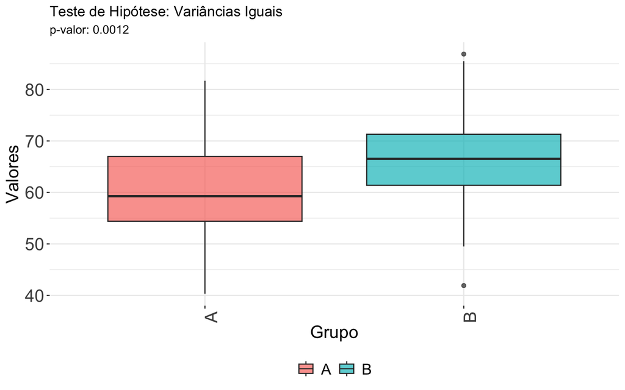

```r
ggplot(dados, aes(x = Grupo, y = Valores, fill = Grupo)) +
  geom_boxplot(alpha = 0.7) +
  labs(title = "Teste de Hipótese: Variâncias Iguais",
       subtitle = paste("p-valor:", round(teste_igual$p.value, 4)),
       x = "Grupo",
       y = "Valores") +
  theme_bw() +
  theme(axis.text.x = element_text(size = 16, angle = 90, hjust = 1),
        axis.title.x = element_text(size = 16),
        axis.text.y = element_text(size = 16),
        axis.title.y = element_text(size = 16),
        panel.border = element_blank(),
        legend.position = "bottom",
        legend.title = element_blank(),
        legend.text = element_text(size = 14))
```

##### Exemplo: Simulação com variâncias diferentes

```r
# Simulação de dados
set.seed(123)
grupo_C = rnorm(50, mean = 60, sd = 10)  # Média 60, desvio padrão 10
grupo_C
```

```
 [1] 54.39524 57.69823 75.58708 60.70508 61.29288 77.15065 64.60916 47.34939
 [9] 53.13147 55.54338 72.24082 63.59814 64.00771 61.10683 54.44159 77.86913
[17] 64.97850 40.33383 67.01356 55.27209 49.32176 57.82025 49.73996 52.71109
[25] 53.74961 43.13307 68.37787 61.53373 48.61863 72.53815 64.26464 57.04929
[33] 68.95126 68.78133 68.21581 66.88640 65.53918 59.38088 56.94037 56.19529
[41] 53.05293 57.92083 47.34604 81.68956 72.07962 48.76891 55.97115 55.33345
[49] 67.79965 59.16631
```

```r
grupo_D = rnorm(50, mean = 65, sd = 15)  # Média 65, desvio padrão 15
grupo_D
```

```
 [1] 68.79978 64.57180 64.35694 85.52903 61.61344 87.74706 41.76871 73.76921
 [9] 66.85781 68.23912 70.69459 57.46515 60.00189 49.72137 48.92313 69.55293
[17] 71.72315 65.79506 78.83401 95.75127 57.63453 30.36247 80.08608 54.36199
[25] 54.67987 80.38357 60.72840 46.68923 67.71955 62.91663 65.08646 70.77921
[33] 59.44010 74.66565 61.69270 69.97673 81.45259 71.52772 60.11103 82.23211
[41] 79.90256 73.22595 68.58098 55.58141 85.40979 55.99611 97.80999 87.98916
[49] 61.46449 49.60369
```

```r
# Teste t com variâncias diferentes
teste_diferente = t.test(grupo_C, grupo_D, var.equal = FALSE)
teste_diferente
```

```
    Welch Two Sample t-test

data:  grupo_C and grupo_D
t = -2.9477, df = 86.454, p-value = 0.004116
alternative hypothesis: true difference in means is not equal to 0
95 percent confidence interval:
 -11.472878  -2.231299
sample estimates:
mean of x mean of y
 60.34404  67.19612
```

```r
# Visualização
dados2 = data.frame(Grupo = c(rep("C", 50), rep("D", 50)),
                    Valores = c(grupo_C, grupo_D))

head(dados2)
```

```
  Grupo  Valores
1     C 54.39524
2     C 57.69823
3     C 75.58708
4     C 60.70508
5     C 61.29288
6     C 77.15065
```

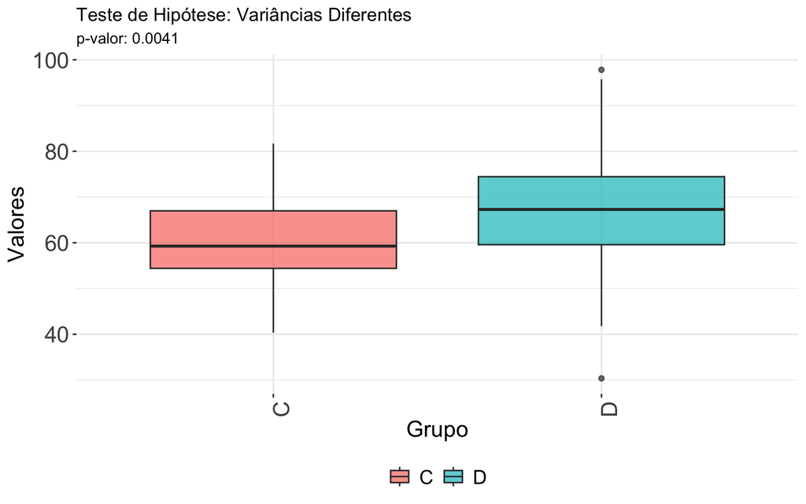

```r
ggplot(dados2, aes(x = Grupo, y = Valores, fill = Grupo)) +
  geom_boxplot(alpha = 0.7) +
  labs(title = "Teste de Hipótese: Variâncias Diferentes",
       subtitle = paste("p-valor:", round(teste_diferente$p.value, 4)),
       x = "Grupo",
       y = "Valores") +
  theme_bw() +
  theme(axis.text.x = element_text(size = 16, angle = 90, hjust = 1),
        axis.title.x = element_text(size = 16),
        axis.text.y = element_text(size = 16),
        axis.title.y = element_text(size = 16),
        panel.border = element_blank(),
        legend.position = "bottom",
        legend.title = element_blank(),
        legend.text = element_text(size = 14))
```

#### O impacto da variância sobre a decisão

O impacto de variâncias diferentes pode ser avaliado simulando amostras provenientes de populações com distintas média e variâncias crescentes. À medida que a diferença nas variâncias aumenta, a suposição de homogeneidade de variâncias é violada, afetando o p-valor do teste de hipótese.

```r
# Função para simular e calcular p-valor
simula_comparacao = function(sd_g1, sd_g2, n1 = 10, n2 = 1000) {
  set.seed(123) # Garantir reprodutibilidade
  grupo1 = rnorm(n1, mean = 50, sd = sd_g1)
  grupo2 = rnorm(n2, mean = 55, sd = sd_g2)

  # Teste t
  teste_igual = t.test(grupo1, grupo2, var.equal = TRUE)
  teste_diff = t.test(grupo1, grupo2, var.equal = FALSE)

  # Retorna valores-p
  return(data.frame(SD_Grupo1 = sd_g1,
                    SD_Grupo2 = sd_g2,
                    P_Igual = teste_igual$p.value,
                    P_Diferente = teste_diff$p.value))
}

# Simular para variâncias crescentes
variancias = seq(1, 20, by = 1)
variancias
```

```
 [1]  1  2  3  4  5  6  7  8  9 10 11 12 13 14 15 16 17 18 19 20
```

```r
resultados = do.call(rbind,
                     lapply(variancias, function(v) simula_comparacao(sd_g1 = 5, sd_g2 = v)))
head(resultados)
```

```
  SD_Grupo1 SD_Grupo2      P_Igual P_Diferente
1         5         1 7.320740e-38  0.01318846
2         5         2 1.128595e-12  0.01298642
3         5         3 1.195711e-06  0.01278903
4         5         4 2.324192e-04  0.01259627
5         5         5 3.034765e-03  0.01240822
6         5         6 1.304430e-02  0.01222515
```

```r
# Visualizar
resultados_long = resultados |>
  pivot_longer(cols = c("P_Igual", "P_Diferente"),
               names_to = "Teste", values_to = "P_Valor")
head(resultados_long)
```

```
# A tibble: 6 × 4
  SD_Grupo1 SD_Grupo2 Teste        P_Valor
      <dbl>     <dbl> <chr>          <dbl>
1         5         1 P_Igual     7.32e-38
2         5         1 P_Diferente 1.32e- 2
3         5         2 P_Igual     1.13e-12
4         5         2 P_Diferente 1.30e- 2
5         5         3 P_Igual     1.20e- 6
6         5         3 P_Diferente 1.28e- 2
```

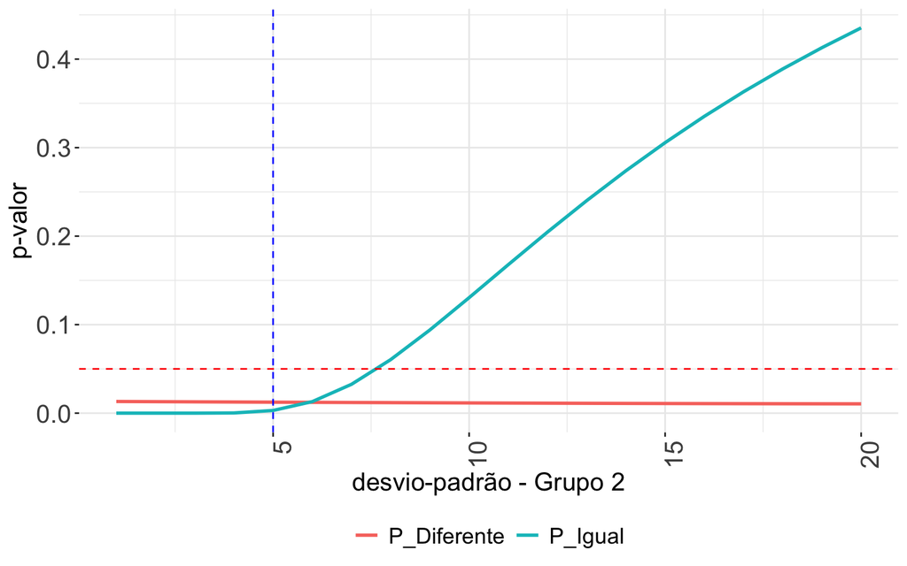

```r
ggplot(resultados_long, aes(x = SD_Grupo2, y = P_Valor, color = Teste)) +
  geom_line(size = 1) +
  geom_hline(yintercept = 0.05, linetype = "dashed", color = "red") +
  geom_vline(xintercept = 5, linetype = "dashed", color = "blue") +
  labs(x = "desvio-padrão - Grupo 2",
       y = "p-valor") +
  theme_bw() +
  theme(axis.text.x = element_text(size = 16, angle = 90, hjust = 1),
        axis.title.x = element_text(size = 16),
        axis.text.y = element_text(size = 16),
        axis.title.y = element_text(size = 16),
        panel.border = element_blank(),
        legend.position = "bottom",
        legend.title = element_blank(),
        legend.text = element_text(size = 14))
```

Portanto, é essencial avaliar se as variâncias das duas populações são iguais ou diferentes, pois essa informação influencia diretamente a escolha do teste estatístico adequado.

Para determinar se as variâncias são iguais ou não, é possível realizar um teste de hipótese específico, como o teste F, que avalia a homogeneidade das variâncias entre os grupos. Neste caso, testa-se

$$H_0: \dfrac{\sigma^2_1}{\sigma^2_2} = 1 \quad \text{(as variâncias são
iguais)} \\
H_1: \dfrac{\sigma^2_1}{\sigma^2_2} \neq 1 \quad \text{(as variâncias
são diferentes)}$$

Esse teste nos fornece uma base estatística para decidir qual abordagem é mais adequada para comparar as médias das populações.

O R possui uma função pronta para realizar o teste F de igualdade de variâncias, que é a função `var.test()`. Esse teste é utilizado para verificar se duas populações têm variâncias iguais, seguindo a teoria descrita abaixo.

#### Teste F de Igualdade de Variâncias

Sejam $X_1 \sim N(\mu_1, \sigma_1^2)$ e $X_2 \sim N(\mu_2, \sigma_2^2)$, e suponha que sorteamos amostras de tamanho $n_1$ e $n_2$ das populações $X_1$ e $X_2$, respectivamente. Considere as seguintes hipóteses
$$H_0: \dfrac{\sigma^2_1}{\sigma^2_2} = 1 \ \ \ \ \ \ \ \ \ \ \ \ \ \ \
H_1: \dfrac{\sigma^2_1}{\sigma^2_2} \neq 1$$
Tomando os estimadores para cada uma das variâncias, $S_1^2$ e $S_2^2$, respectivamente, segue que:

$$U = \frac{(n_1 - 1) S_1^2}{\sigma_1^2} \sim \chi^2_{n_1 - 1}$$

e

$$V = \frac{(n_2 - 1) S_2^2}{\sigma_2^2} \sim \chi^2_{n_2 - 1}$$

A estatística de teste F para a igualdade de variâncias segue a distribuição F-Snedecor com $n_1 - 1$ e $n_2 - 1$ graus de liberdade:

$$F = \frac{S_1^2 / \sigma_1^2}{S_2^2 / \sigma_2^2} = \frac{S_1^2}{S_2^2}
\sim F_{n_1 - 1, n_2 - 1}$$

onde $S_1^2$ e $S_2^2$ são os estimadores das variâncias das duas amostras, e a distribuição $F$ tem $n_1 - 1$ e $n_2 - 1$ graus de liberdade.

Para testar a hipótese de igualdade de variâncias entre duas populações, podemos utilizar a seguinte estatística de teste:

$$F = \frac{S_1^2}{S_2^2} \sim F(n_1 - 1, n_2 - 1)$$

onde $S_1^2$ e $S_2^2$ são as variâncias amostrais das duas populações e $n_1$ e $n_2$ são os tamanhos das amostras. Essa estatística segue uma distribuição F com $n_1 - 1$ e $n_2 - 1$ graus de liberdade.

**Intuição:** Se a razão $\frac{S_1^2}{S_2^2}$ estiver muito distante de 1, isso indica que as variâncias são substancialmente diferentes. Nesse caso, devemos rejeitar a hipótese nula de igualdade das variâncias. Se a razão estiver próxima de 1, a hipótese nula é mais plausível, indicando que as variâncias das duas populações são semelhantes.

##### Exemplo

```r
# Dados de variância das amostras
variancia_fabrica1 = 25  # Variância da Fábrica 1
variancia_fabrica2 = 18  # Variância da Fábrica 2
tamanho_amostra1 = 30    # Tamanho da amostra da Fábrica 1
tamanho_amostra2 = 30    # Tamanho da amostra da Fábrica 2

# Realizando o teste F de igualdade de variâncias
teste_f = var.test(rnorm(tamanho_amostra1, mean = 50, sd = sqrt(variancia_fabrica1)),
                   rnorm(tamanho_amostra2, mean = 50, sd = sqrt(variancia_fabrica2)))
teste_f
```

```
    F test to compare two variances

data:  rnorm(tamanho_amostra1, mean = 50, sd = sqrt(variancia_fabrica1)) and rnorm(tamanho_amostra2, mean = 50, sd = sqrt(variancia_fabrica2))
F = 2.3754, num df = 29, denom df = 29, p-value = 0.02289
alternative hypothesis: true ratio of variances is not equal to 1
95 percent confidence interval:
 1.130616 4.990747
sample estimates:
ratio of variances
           2.37542
```

```r
# Tomada de decisão
if (teste_f$p.value < 0.05) {
  resultado = "Rejeita H0 - As variâncias das duas fábricas são diferentes."
} else {
  resultado = "Não rejeita H0 - Não há evidência suficiente para afirmar que as variâncias são diferentes."
}

# Exibindo resultados
cat("p-valor:", teste_f$p.value, "\n")
```

```
p-valor: 0.02288865
```

```r
cat("Decisão:", resultado, "\n")
```

```
Decisão: Rejeita H0 - As variâncias das duas fábricas são diferentes.
```

## Teste de Hipótese para a Diferença entre Proporções

O teste de hipótese para a diferença entre duas proporções é utilizado para comparar duas proporções populacionais e determinar se existe uma diferença estatisticamente significativa entre elas. Este teste é comumente usado quando queremos verificar, por exemplo, se a proporção de sucesso em dois grupos ou tratamentos é diferente.

Sejam $p_1$ e $p_2$ as proporções de sucesso nas duas populações (ou amostras) que estamos comparando. A hipótese nula ($H_0$) e a hipótese alternativa ($H_1$) para o teste são formuladas da seguinte forma:

$$H_0: p_1 = p_2 \quad \text{(não há diferença entre as proporções)}$$

$$H_1: p_1 \neq p_2 \quad \text{(há diferença entre as proporções)}$$

A estatística de teste para a diferença entre proporções é dada por:

$$Z = \frac{\hat{p}_1 - \hat{p}_2}{\sqrt{\hat{p}(1 - \hat{p}) \left(
\frac{1}{n_1} + \frac{1}{n_2} \right)}} \dot\sim N(0,1)$$

onde:

- $\hat{p}_1$ e $\hat{p}_2$ são as proporções amostrais das duas amostras
- $\hat{p}$ é a proporção combinada de sucesso nas duas amostras, calculada por:

$$\hat{p} = \frac{x_1 + x_2}{n_1 + n_2}$$

em que:

- $x_1$ e $x_2$ são os números de sucessos nas duas amostras
- $n_1$ e $n_2$ são os tamanhos das amostras.

A distribuição de $Z$ segue uma distribuição normal padrão sob a hipótese nula. O p-valor é calculado a partir da estatística de teste $Z$ e comparado com o nível de significância ($\alpha$) para decidir se rejeitamos ou não a hipótese nula.

As decisões possíveis são:

- Se o p-valor for menor que o nível de significância ($\alpha$), rejeitamos $H_0$ e concluímos que as proporções são significativamente diferentes.
- Se o p-valor for maior que $\alpha$, não rejeitamos $H_0$, sugerindo que não há diferença significativa entre as proporções.

Este teste pode ser bilateral ou unilateral, dependendo da hipótese alternativa formulada. No caso de uma hipótese unilateral (por exemplo, $p_1 > p_2$ ou $p_1 < p_2$), o cálculo do p-valor será ajustado para refletir essa direção específica da diferença.

```r
# Definindo os dados
sucessos_grupo1 = 40  # número de sucessos no grupo 1
total_grupo1 = 100    # total de indivíduos no grupo 1

sucessos_grupo2 = 50  # número de sucessos no grupo 2
total_grupo2 = 120    # total de indivíduos no grupo 2

# Calculando as proporções de sucesso
p1 = sucessos_grupo1 / total_grupo1
p2 = sucessos_grupo2 / total_grupo2

# Calculando a proporção combinada
p_pool = (sucessos_grupo1 + sucessos_grupo2) / (total_grupo1 + total_grupo2)

# Calculando a estatística Z para a diferença entre proporções
z = (p1 - p2) / sqrt(p_pool * (1 - p_pool) * (1 / total_grupo1 + 1 / total_grupo2))

# Calculando o valor-p (bilateral)
p_value = 2 * (1 - pnorm(abs(z)))
p_value
```

```
[1] 0.8023122
```

```r
# Tomada de decisão
if (p_value < 0.05) {
  resultado = "Rejeita H0 - Existe uma diferença significativa entre as proporções."
} else {
  resultado = "Não rejeita H0 - Não existe uma diferença significativa entre as proporções."
}

# Exibindo resultados
cat("p-valor:", p_value, "\n")
```

```
p-valor: 0.8023122
```

```r
cat("Decisão:", resultado, "\n")
```

```
Decisão: Não rejeita H0 - Não existe uma diferença significativa entre as proporções.
```

#### Função `prop.test()`

O R possui uma função pronta para realizar o teste de diferença entre proporções. Essa função é o `prop.test()`, que realiza o teste de hipótese para a diferença de proporções entre duas ou mais amostras.

##### Exemplo

Suponha que uma empresa quer verificar se a proporção de clientes satisfeitos em uma loja A ($p_1$) é menor do que a proporção de clientes satisfeitos em uma loja B ($p_2$).

- Na loja A, 80 de 200 clientes estão satisfeitos.
- Na loja B, 120 de 250 clientes estão satisfeitos.

A empresa quer testar se a proporção de clientes satisfeitos na loja A é menor do que na loja B, considerando nível de significância de 5%. Assim, as hipóteses a serem testadas são:

$$H_0: p_A = p_B \ \ \ \ \ \ \ \ \ \ \ \ \ \ \ \ \ \ \
H_1: p_A < p_B$$

```r
# Dados
sucessos_A = 80  # número de clientes satisfeitos na loja A
total_A = 200    # total de clientes na loja A

sucessos_B = 120  # número de clientes satisfeitos na loja B
total_B = 250     # total de clientes na loja B

# Realizando o teste de proporções com prop.test
teste = prop.test(c(sucessos_A, sucessos_B), c(total_A, total_B), alternative = "less")
teste
```

```
    2-sample test for equality of proportions with continuity correction

data:  c(sucessos_A, sucessos_B) out of c(total_A, total_B)
X-squared = 2.5651, df = 1, p-value = 0.05462
alternative hypothesis: less
95 percent confidence interval:
 -1.000000000  0.001622414
sample estimates:
prop 1 prop 2
  0.40   0.48
```

```r
# Tomada de decisão
if (teste$p.value < 0.05) {
  resultado = "Rejeita H0 - A proporção de satisfação na loja A é menor que na loja B."
} else {
  resultado = "Não rejeita H0 - Não há evidência suficiente para afirmar que a proporção na loja A é menor que na loja B."
}

# Exibindo resultados
cat("p-valor:", teste$p.value, "\n")
```

```
p-valor: 0.05462239
```

```r
cat("Decisão:", resultado, "\n")
```

```
Decisão: Não rejeita H0 - Não há evidência suficiente para afirmar que a proporção na loja A é menor que na loja B.
```

> **Desafio:** Simule pares independentes de 500 amostras de populações normais de tamanho 40 cada uma, sendo a primeira com média 40 e variância 9 e a segunda com média 44 e variância 10. Para cada par de amostras, verifique a igualdade das variâncias e, em seguida, com base no resultado, verifique se as médias são iguais. Note que dependendo do resultado do teste de igualdade das variâncias, o teste para igualdade das médias será diferente. Faça uma função que retorne um dataframe contendo o valor da estatística de teste, o p-valor e a decisão em cada amostra.